# ME397 Engineering Data Analysis

# Final Projects - Loan Delinquency prediction using machine learning

# Zhaowei Liang

```r
#import libraries
#visulization libraries
library(ggplot2)

#Machine Learning libraries

library(caret)
library(xgboost)
library(mlbench)
library(randomForest)
library(stepPlr)
#library(party)
#library(mboost)

#Utilities

library(plyr)
library(dplyr)
library(tidyr)
library(GGally)
#library(parallel)
library(doParallel)
#library(doMC)
library("Hmisc")
#registerDoMC(cores = 18)
```

```r
#import data
raw <- read.csv("LIANG_ZHAOWEI_LOANDATA.csv")
```

```r
# Confirm loaded data
dim(raw)
```

```
## [1] 113937     81
```

## 1. Data Clearning

```r
# take a brief look of all features
str(raw)
```

```
## 'data.frame':    113937 obs. of  81 variables:
##  $ ListingKey                         : Factor w/ 113066 levels "00003546482094282EF90E5",..: 7180 7193 6647 6669 6686 6689 6699 6706 6687 6687 ...
##  $ ListingNumber                      : int  193129 1209647 81716 658116 909464 1074836 750899 768193 1023355 1023355 ...
##  $ ListingCreationDate                : Factor w/ 113064 levels "2005-11-09 20:44:28.847000000",..: 14184 111894 6429 64760 85967 100310 72556 74019 97834 97834 ...
##  $ CreditGrade                        : Factor w/ 9 levels "","A","AA","B",..: 5 1 8 1 1 1 1 1 1 1 ...
##  $ Term                               : int  36 36 36 36 36 60 36 36 36 36 ...
##  $ LoanStatus                         : Factor w/ 12 levels "Cancelled","Chargedoff",..: 3 4 3 4 4 4 4 4 4 4 ...
##  $ ClosedDate                         : Factor w/ 2803 levels "","2005-11-25 00:00:00",..: 1138 1 1263 1 1 1 1 1 1 1 ...
##  $ BorrowerAPR                        : num  0.165 0.12 0.283 0.125 0.246 ...
##  $ BorrowerRate                       : num  0.158 0.092 0.275 0.0974 0.2085 ...
##  $ LenderYield                        : num  0.138 0.082 0.24 0.0874 0.1985 ...
##  $ EstimatedEffectiveYield            : num  NA 0.0796 NA 0.0849 0.1832 ...
##  $ EstimatedLoss                      : num  NA 0.0249 NA 0.0249 0.0925 ...
##  $ EstimatedReturn                    : num  NA 0.0547 NA 0.06 0.0907 ...
##  $ ProsperRating..numeric.            : int  NA 6 NA 6 3 5 2 4 7 7 ...
```

[output cut: 67 more lines]

### 1.1 Drop evidentally irrelevant or unnecessary information

[1] “ListingKey”  
[2] “ListingNumber”  
[24] “GroupKey”  
[51] “LoanKey”  
[67] “MemberKey”

```r
# drop Administrative keys
r1 <- c("ListingKey","ListingNumber", "GroupKey", "LoanKey", "MemberKey", "LoanNumber")
#preserve raw for future reference
clean <- raw[,!names(raw) %in% r1]

# Drop Highly Correlated Keys
r2 <- c("CreditScoreRangeUpper", "CreditGrade", "ProsperRating..Alpha.")
clean <- clean[,!names(clean) %in% r2]

# Drop all columns related to dates, since the model we build should not be
# depend on any specific date
r3 <- c("ListingCreationDate", "ClosedDate", "DateCreditPulled",
        "LoanOriginationDate", "LoanOriginationQuarter", "MemberKey")
clean <- clean[,!names(clean) %in% r3]

# Any feature that related to loans with "Current" Status should be droped.
# This analysis is based on completed or overdue/charged off/Defaulted loans.

r4 <- c("LoanCurrentDaysDelinquent", "LoanFirstDefaultedCycleNumber", "LoanMonthsSinceOrigination", "LP_CustomerPayments",
         "LP_CustomerPrincipalPayments", "LP_InterestandFees", "LP_ServiceFees", "LP_CollectionFees", "LP_GrossPrincipalLoss",
         "LP_NetPrincipalLoss","LP_NonPrincipalRecoverypayments")
clean <- clean[,!names(clean) %in% r4]
```

### 1.3 Fill out missing values

```r
# Some value is missing because they are zero according to the data dictionary
# fill them with 0
clean[is.na(clean$TotalProsperLoans),"TotalProsperLoans"]<- median(0,na.rm = T)
clean[is.na(clean$TotalProsperPaymentsBilled),"TotalProsperPaymentsBilled"]<- mean(0,na.rm = T)
clean[is.na(clean$OnTimeProsperPayments),"OnTimeProsperPayments"]<- mean(0,na.rm = T)
clean[is.na(clean$ProsperPaymentsLessThanOneMonthLate),"ProsperPaymentsLessThanOneMonthLate"]<- mean(0,na.rm = T)
clean[is.na(clean$ProsperPaymentsOneMonthPlusLate),"ProsperPaymentsOneMonthPlusLate"]<- mean(0,na.rm = T)
clean[is.na(clean$ProsperPrincipalBorrowed),"ProsperPrincipalBorrowed"]<- mean(0,na.rm = T)
clean[is.na(clean$ProsperPrincipalOutstanding),"ProsperPrincipalOutstanding"]<- mean(0,na.rm = T)
clean[is.na(clean$CurrentCreditLines),"CurrentCreditLines"]<- mean(0,na.rm = T)
```

```r
#Test
sum(is.na(clean$TotalProsperLoans))
```

```
## [1] 0
```

```r
# Some numerical columns with low percentage of NA value can be filled with
# mean values
clean[is.na(clean$OpenCreditLines),"OpenCreditLines"]<-mean(clean$OpenCreditLines,na.rm = T)
clean[is.na(clean$AmountDelinquent),"AmountDelinquent"]<-mean(clean$AmountDelinquent,na.rm = T)
clean[is.na(clean$PublicRecordsLast12Months),"PublicRecordsLast12Months"]<-mean(clean$PublicRecordsLast12Months,na.rm = T)
clean[is.na(clean$RevolvingCreditBalance),"RevolvingCreditBalance"]<-mean(clean$RevolvingCreditBalance,na.rm = T)
clean[is.na(clean$BankcardUtilization),"BankcardUtilization"]<-mean(clean$BankcardUtilization,na.rm = T)
clean[is.na(clean$AvailableBankcardCredit),"AvailableBankcardCredit"]<-mean(clean$AvailableBankcardCredit,na.rm = T)
clean[is.na(clean$TotalTrades),"TotalTrades"]<-mean(clean$TotalTrades,na.rm = T)
clean[is.na(clean$TradesNeverDelinquent..percentage.),"TradesNeverDelinquent..percentage."]<-mean(clean$TradesNeverDelinquent..percentage.,na.rm = T)
clean[is.na(clean$TradesOpenedLast6Months),"TradesOpenedLast6Months"]<-mean(clean$TradesOpenedLast6Months,na.rm = T)
clean[is.na(clean$InquiriesLast6Months),"InquiriesLast6Months"]<-mean(clean$InquiriesLast6Months,na.rm = T)
clean[is.na(clean$TotalInquiries),"TotalInquiries"]<-mean(clean$TotalInquiries,na.rm = T)
clean[is.na(clean$CurrentDelinquencies),"CurrentDelinquencies"]<-mean(clean$CurrentDelinquencies,na.rm = T)
clean[is.na(clean$DelinquenciesLast7Years),"DelinquenciesLast7Years"]<-mean(clean$DelinquenciesLast7Years,na.rm = T)
clean[is.na(clean$DebtToIncomeRatio),"DebtToIncomeRatio"] <- mean((clean$MonthlyLoanPayment / (clean$StatedMonthlyIncome + 1)),na.rm = T)
```

```r
#test
sum(is.na(clean$OpenCreditLines))
```

```
## [1] 0
```

```r
# Features with high standard deviation and low percentage of missing value will
# replaced by medians
clean[is.na(clean$EstimatedLoss),"EstimatedLoss"]=
  median(clean$EstimatedLoss,na.rm = T)

sum(is.na(clean$EstimatedLoss))
```

```
## [1] 0
```

```r
clean$EstimatedReturn <-
  mean((clean$EstimatedEffectiveYield - clean$EstimatedLoss),na.rm = T)

sum(is.na(clean$EstimatedReturn))
```

```
## [1] 0
```

```r
clean[is.na(clean$ProsperScore),"ProsperScore"]<-
  median(clean$ProsperScore,na.rm = T)

sum(is.na(clean$ProsperScore))
```

```
## [1] 0
```

```r
# Some missing values can be calculated based on  clear relationship to other
# features
borrower_fees <- as.numeric(clean$BorrowerAPR)-as.numeric(clean$BorrowerRate)
borrower_fees_median <- mean(c(borrower_fees))
clean[is.na(clean$BorrowerAPR),"BorrowerAPR"] <-
  median(clean$BorrowerAPR,na.rm = T)

sum(is.na(clean$BorrowerAPR))
```

```
## [1] 0
```

```r
estimated_loss_from_fees  <- as.numeric(clean$BorrowerRate)-as.numeric(clean$EstimatedEffectiveYield)
borrower_fees_median = mean(c(estimated_loss_from_fees))
clean[is.na(clean$EstimatedEffectiveYield),"EstimatedEffectiveYield"]<- median(clean$EstimatedEffectiveYield,na.rm = T)
sum(is.na(clean$EstimatedEffectiveYield))
```

```
## [1] 0
```

```r
# The Debt to Income Ratio, although some case is not varifiable, can be calculated
# Based on some other values
```

```r
sum(is.na(clean$DebtToIncomeRatio))
```

```
## [1] 0
```

### 1.3 Combine all past due condition into one category = “PastDue”

```r
PastDue <- c("Past Due (>120 days)",
             "Past Due (1-15 days)",
             "Past Due (16-30 days)",
             "Past Due (31-60 days)",
             "Past Due (61-90 days)",
             "Past Due (91-120 days)")
clean$LoanStatus <- as.character(clean$LoanStatus)
clean$LoanStatus[clean$LoanStatus %in% PastDue] <- "PastDue"
```

### 1.4 Deleted Loan data with “Current” Status

Current means the loan is not due yet and we have no other way to determine weahter the borrowers will pay it off or not.

```r
idx <- which(clean$LoanStatus != 'Current')
clean <- clean[idx,]
```

```r
#Test
table(clean$LoanStatus)
```

```
##
##              Cancelled             Chargedoff              Completed
##                      5                  11992                  38074
##              Defaulted FinalPaymentInProgress                PastDue
##                   5018                    205                   2067
```

```r
dim(clean)
```

```
## [1] 57361    56
```

```r
# Group up Delinquent
# Completed loan -> Completed, Others -> Deliquency
clean$LoanStatus[clean$LoanStatus == "Cancelled"] <- "deliquency"
clean$LoanStatus[clean$LoanStatus == "Defaulted"] <- "deliquency"
clean$LoanStatus[clean$LoanStatus == "FinalPaymentInProgress"] <- c("deliquency")
clean$LoanStatus[clean$LoanStatus == "PastDue"] <- "deliquency"
clean$LoanStatus[clean$LoanStatus == "Chargedoff"] <- "deliquency"
```

```r
# Check the cleaned dataset
dim(clean)
```

```
## [1] 57361    56
```

```r
loandata <- clean
```

## 2 Explotory Data Analysis

### 2.1 Worth Investigating?

```r
prop.table(table(loandata$LoanStatus))
```

```
##
##  Completed deliquency
##  0.6637611  0.3362389
```

### 2.2 Credit Score vs Deliquncy

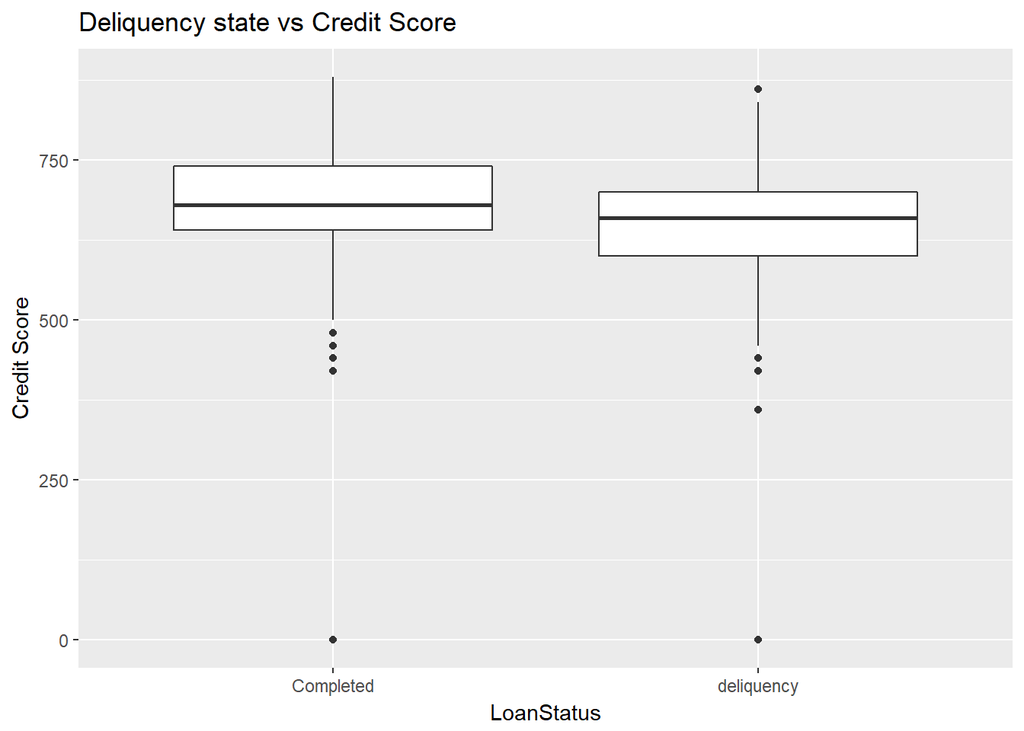

```r
ggplot(data = loandata, aes(x = LoanStatus, y = CreditScoreRangeLower)) +
      geom_boxplot() +
  labs(title ="Deliquency state vs Credit Score", y = "Credit Score")
```

### 2.3 Categorical Variables - Listing Categories

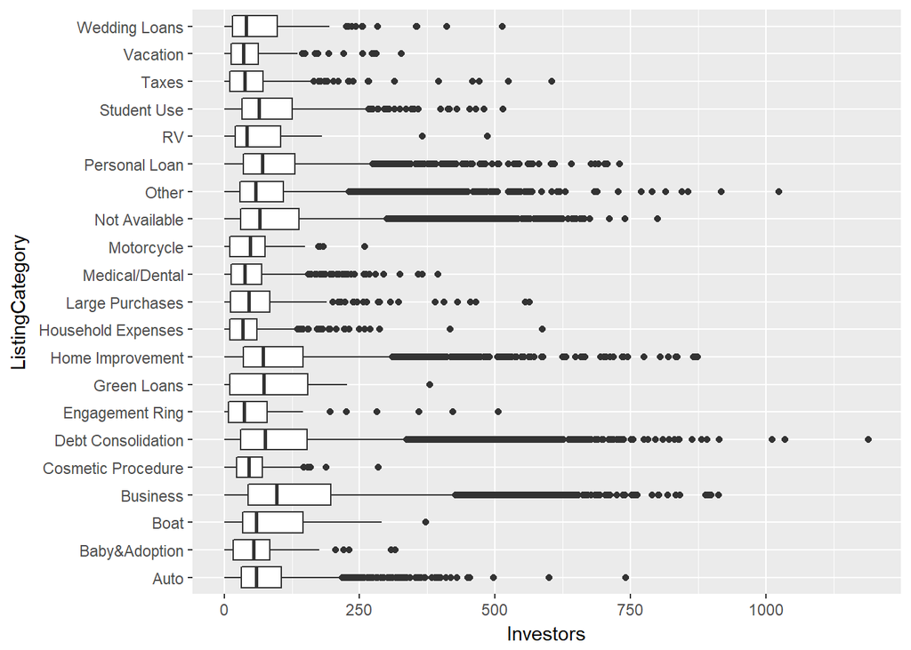

```r
# the listing Category is in numerical form. For a better view, I mapped their English Description

CategoryName <- c("Not Available", "Debt Consolidation", "Home Improvement",
                  "Business", "Personal Loan",
                     "Student Use", "Auto", "Other", "Baby&Adoption", "Boat",
                  "Cosmetic Procedure",
                      "Engagement Ring", "Green Loans","Household Expenses",
                  "Large Purchases", "Medical/Dental",
                     "Motorcycle", "RV", "Taxes", "Vacation", "Wedding Loans")
#create a new column and map full category name on this new column
loandata$ListingCategory <- CategoryName[(loandata$ListingCategory..numeric.)+1]

ggplot(data = loandata, aes(ListingCategory, Investors)) + geom_boxplot() +
  coord_flip()
```

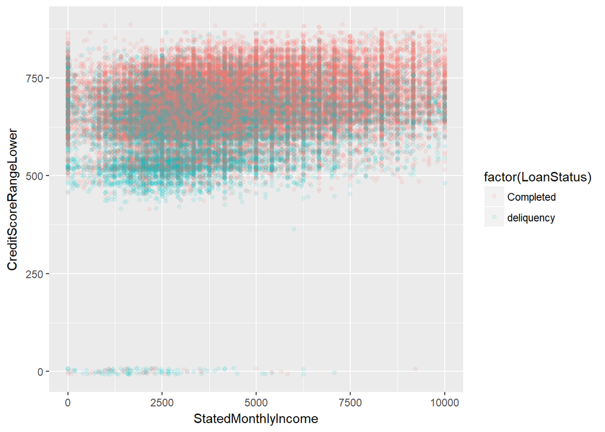

```r
ggplot(data = loandata,
       aes(StatedMonthlyIncome, CreditScoreRangeLower,
           colour = factor(LoanStatus))) +
geom_jitter(alpha = 0.1) + xlim(0, 10000)
```

### 2.5 Investors vs Credit Score and Loan Original Amount

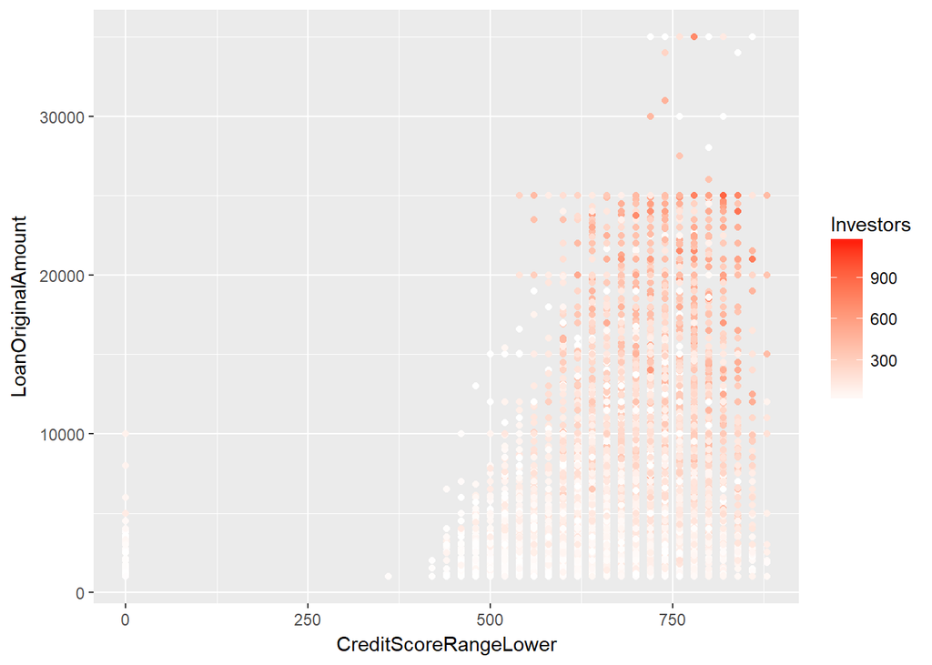

```r
ggplot(data = loandata, aes(x = CreditScoreRangeLower, y = LoanOriginalAmount)) +
         geom_point(aes(colour = Investors)) +
        scale_colour_gradient(low = "white", high = "red")
```

```r
# To fully extend the benefit of logistic regression, bankcard utlizations
# are grouped into few bins instead of using real value
loandata$BankCardUse[loandata$BankcardUtilization < quantile(loandata$BankcardUtilization,probs = 0.25, "na.rm" = TRUE)] <- 0.2

loandata$BankCardUse[loandata$BankcardUtilization >= quantile(loandata$BankcardUtilization,probs = 0.25, "na.rm" = TRUE) &loandata$BankcardUtilization <
                       quantile(loandata$BankcardUtilization,probs = 0.5, "na.rm"= TRUE)] <- 0.5

loandata$BankCardUse[loandata$BankcardUtilization >= quantile(loandata$BankcardUtilization,probs = 0.5, "na.rm" = TRUE)&loandata$BankcardUtilization <
                       quantile(loandata$BankcardUtilization,probs = 0.75, "na.rm" = TRUE)] <- 0.75

loandata$BankCardUse[loandata$BankcardUtilization >= 0.75] <- 0.9
```

#### 3.1.2 Dimension reduction

```r
# Preserve the cleaned dataset for future reference
LoanML <- cbind(loandata)
```

```r
mr1 <- c("CreditGrade", "BorrowerAPR", "LenderYield", "EstimatedEffectiveYield",
        "EstimatedLoss", "EstimatedReturn", "ProsperRating (Alpha)",
        "Occupation", "CurrentlyInGroup", "GroupKey", "IncomeRange", "PercentFunded")

LoanML <- LoanML[,!names(LoanML) %in% mr1]
```

```r
str(LoanML)
```

```
## 'data.frame':    57361 obs. of  49 variables:
##  $ Term                               : int  36 36 36 36 36 36 36 36 60 36 ...
##  $ LoanStatus                         : chr  "Completed" "Completed" "Completed" "deliquency" ...
##  $ BorrowerRate                       : num  0.158 0.275 0.133 0.143 0.318 ...
##  $ ProsperRating..numeric.            : int  NA NA NA 5 1 NA NA 3 2 6 ...
##  $ ProsperScore                       : num  6 6 6 4 5 6 6 5 3 9 ...
##  $ ListingCategory..numeric.          : int  0 0 0 1 13 0 0 15 1 1 ...
##  $ BorrowerState                      : Factor w/ 52 levels "","AK","AL","AR",..: 7 12 1 3 11 1 24 16 36 7 ...
##  $ EmploymentStatus                   : Factor w/ 9 levels "","Employed",..: 9 4 3 2 6 4 3 2 2 3 ...
##  $ EmploymentStatusDuration           : int  2 NA 19 1 121 NA 36 3 25 10 ...
##  $ IsBorrowerHomeowner                : Factor w/ 2 levels "False","True": 2 1 1 1 2 2 1 1 1 2 ...
##  $ CreditScoreRangeLower              : int  640 480 640 680 700 760 620 680 660 700 ...
##  $ FirstRecordedCreditLine            : Factor w/ 11586 levels "","1947-08-24 00:00:00",..: 8639 8927 8310 6853 7696 4555 9255 7424 776 8094 ...
##  $ CurrentCreditLines                 : num  5 0 2 9 10 0 4 7 7 16 ...
##  $ OpenCreditLines                    : num  4 9.26 2 7 9 ...
```

[output cut: 35 more lines]

```r
# Drop more columns that irrelevant to the analysis, some features can be well
# descripbed by other feature
mr2 <- c("ListingCategory", # a feature for plot only
         "BorrowerState", #Way too many categorical variable with not that much information
         "FirstRecordedCreditLine", #Credit History already described by other features
         "BankCardUse", #grouped bankcard utlization, decide not to use
         "EmploymentStatusDuration",
         "ScorexChangeAtTimeOfListing", # way too many missing values without remdials
         "ProsperRating..numeric.", # closely related to Prosper Score
         "C"
         )

LoanML <- LoanML[,!names(LoanML) %in% mr2]
```

```r
#Transfer ListingCategory to factor
LoanML$ListingCategory..numeric. <- factor(LoanML$ListingCategory..numeric.)
```

```r
table(LoanML$EmploymentStatus)
```

```
##
##                    Employed     Full-time Not available  Not employed
##          2255         18393         25039          5347           587
##         Other     Part-time       Retired Self-employed
##           924          1064           703          3049
```

```r
# Convert boolean value for IsBorrowerHomeowner to 1 and 0
LoanML$IsBorrowerHomeowner <- as.integer(as.logical(LoanML$IsBorrowerHomeowner))
head(LoanML$IsBorrowerHomeowner)
```

```
## [1] 1 0 0 0 1 1
```

```r
# COnvert boolean value for IncomeVerifiable to 1 and 0

LoanML$IncomeVerifiable <- as.integer(as.logical(LoanML$IncomeVerifiable))
head(LoanML$IncomeVerifiable)
```

```
## [1] 1 1 1 1 1 1
```

```r
# convert EmploymentStatus to either employed or not, consider not available as
# unemployed

#LoanML$EmploymentStatus[LoanML$EmploymentStatus == "Employed"] <- "a"
#LoanML$EmploymentStatus[LoanML$EmploymentStatus == "Full-time"] <- as.integer(1)
#LoanML$EmploymentStatus[LoanML$EmploymentStatus == "Not available"] <- as.integer(0)
#LoanML$EmploymentStatus[LoanML$EmploymentStatus == "Not employed"] <- as.integer(0)
#LoanML$EmploymentStatus[LoanML$EmploymentStatus == "Other"] <- as.integer(0)
#LoanML$EmploymentStatus[LoanML$EmploymentStatus == "Part-time"] <- as.integer(1)
#$EmploymentStatus[LoanML$EmploymentStatus == "Retired"] <- as.integer(0)
#LoanML$EmploymentStatus[LoanML$EmploymentStatus == "Self-employed"] <- as.integer(1)
#LoanML$EmploymentStatus[LoanML$EmploymentStatus == ""] <- as.integer(0)
```

#### 3.1.3 Encode the response variable

```r
# encode the loanstatus
# Completed -> 1, Deliquncies -> 0
LoanML$LoanStatus[LoanML$LoanStatus == "Completed"] <- as.integer(1)
LoanML$LoanStatus[LoanML$LoanStatus == "deliquency"] <- as.integer(0)
```

```r
# Test
head(LoanML$LoanStatus)
```

```
## [1] "1" "1" "1" "0" "0" "0"
```

#### 3.1.4 encode categorical predictors

```r
# Convert the loanStatus to numeric
LoanML$LoanStatus <- as.numeric(as.character(LoanML$LoanStatus))
```

```r
dmy <- dummyVars("~ .", data = LoanML, fullRank = T)
LoanML <- data.frame(predict(dmy, newdata = LoanML))
```

```r
LoanML$LoanStatus <- as.character(LoanML$LoanStatus)
LoanML$LoanStatus <- as.factor(LoanML$LoanStatus)
```

#### 3.1.5 Check the missing value before run the machine learning model

```r
colSums(is.na(LoanML))
```

```
##                                Term                          LoanStatus
##                                   0                                   0
##                        BorrowerRate                        ProsperScore
##                                   0                                   0
##         ListingCategory..numeric..1         ListingCategory..numeric..2
##                                   0                                   0
##         ListingCategory..numeric..3         ListingCategory..numeric..4
##                                   0                                   0
##         ListingCategory..numeric..5         ListingCategory..numeric..6
##                                   0                                   0
##         ListingCategory..numeric..7         ListingCategory..numeric..8
##                                   0                                   0
##         ListingCategory..numeric..9        ListingCategory..numeric..10
##                                   0                                   0
##        ListingCategory..numeric..11        ListingCategory..numeric..12
##                                   0                                   0
##        ListingCategory..numeric..13        ListingCategory..numeric..14
##                                   0                                   0
##        ListingCategory..numeric..15        ListingCategory..numeric..16
##                                   0                                   0
##        ListingCategory..numeric..17        ListingCategory..numeric..18
##                                   0                                   0
##        ListingCategory..numeric..19        ListingCategory..numeric..20
##                                   0                                   0
##           EmploymentStatus.Employed          EmploymentStatus.Full.time
##                                   0                                   0
##      EmploymentStatus.Not.available       EmploymentStatus.Not.employed
##                                   0                                   0
##              EmploymentStatus.Other          EmploymentStatus.Part.time
##                                   0                                   0
##            EmploymentStatus.Retired      EmploymentStatus.Self.employed
##                                   0                                   0
##                 IsBorrowerHomeowner               CreditScoreRangeLower
##                                   0                                 591
##                  CurrentCreditLines                     OpenCreditLines
##                                   0                                   0
##          TotalCreditLinespast7years               OpenRevolvingAccounts
##                                 697                                   0
##         OpenRevolvingMonthlyPayment                InquiriesLast6Months
##                                   0                                   0
```

[output cut: 13 more lines]

```
##                                   0                                   0
##                 StatedMonthlyIncome                   TotalProsperLoans
##                                   0                                   0
##          TotalProsperPaymentsBilled               OnTimeProsperPayments
##                                   0                                   0
## ProsperPaymentsLessThanOneMonthLate     ProsperPaymentsOneMonthPlusLate
##                                   0                                   0
##            ProsperPrincipalBorrowed         ProsperPrincipalOutstanding
##                                   0                                   0
##                  LoanOriginalAmount                  MonthlyLoanPayment
##                                   0                                   0
##                     Recommendations          InvestmentFromFriendsCount
##                                   0                                   0
##         InvestmentFromFriendsAmount                           Investors
##                                   0                                   0
```

#### 3.1.6 Clean missing values

3 features still have missing values: CreditScoreRangeLower, TotalCreditLinepast7years, PublicRecordsLast10Years. For all of these information we can’t retrive by any means, so we have to drop some rows to avoid missing value

```r
#
LoanML <- LoanML[complete.cases(LoanML), ]
```

```r
# test
colSums(is.na(LoanML))
```

```
##                                Term                          LoanStatus
##                                   0                                   0
##                        BorrowerRate                        ProsperScore
##                                   0                                   0
##         ListingCategory..numeric..1         ListingCategory..numeric..2
##                                   0                                   0
##         ListingCategory..numeric..3         ListingCategory..numeric..4
##                                   0                                   0
##         ListingCategory..numeric..5         ListingCategory..numeric..6
##                                   0                                   0
##         ListingCategory..numeric..7         ListingCategory..numeric..8
##                                   0                                   0
##         ListingCategory..numeric..9        ListingCategory..numeric..10
##                                   0                                   0
##        ListingCategory..numeric..11        ListingCategory..numeric..12
##                                   0                                   0
##        ListingCategory..numeric..13        ListingCategory..numeric..14
##                                   0                                   0
##        ListingCategory..numeric..15        ListingCategory..numeric..16
##                                   0                                   0
##        ListingCategory..numeric..17        ListingCategory..numeric..18
##                                   0                                   0
##        ListingCategory..numeric..19        ListingCategory..numeric..20
##                                   0                                   0
##           EmploymentStatus.Employed          EmploymentStatus.Full.time
##                                   0                                   0
##      EmploymentStatus.Not.available       EmploymentStatus.Not.employed
##                                   0                                   0
##              EmploymentStatus.Other          EmploymentStatus.Part.time
##                                   0                                   0
##            EmploymentStatus.Retired      EmploymentStatus.Self.employed
##                                   0                                   0
##                 IsBorrowerHomeowner               CreditScoreRangeLower
##                                   0                                   0
##                  CurrentCreditLines                     OpenCreditLines
##                                   0                                   0
##          TotalCreditLinespast7years               OpenRevolvingAccounts
##                                   0                                   0
##         OpenRevolvingMonthlyPayment                InquiriesLast6Months
##                                   0                                   0
```

[output cut: 13 more lines]

```
##                                   0                                   0
##                 StatedMonthlyIncome                   TotalProsperLoans
##                                   0                                   0
##          TotalProsperPaymentsBilled               OnTimeProsperPayments
##                                   0                                   0
## ProsperPaymentsLessThanOneMonthLate     ProsperPaymentsOneMonthPlusLate
##                                   0                                   0
##            ProsperPrincipalBorrowed         ProsperPrincipalOutstanding
##                                   0                                   0
##                  LoanOriginalAmount                  MonthlyLoanPayment
##                                   0                                   0
##                     Recommendations          InvestmentFromFriendsCount
##                                   0                                   0
##         InvestmentFromFriendsAmount                           Investors
##                                   0                                   0
```

```r
dim(LoanML)
```

```
## [1] 56664    68
```

```r
# Move the reponse variable to the front
LoanML <- LoanML %>% select(LoanStatus, everything())
```

```r
head(LoanML[,1])
```

```
## [1] 1 1 1 0 0 0
## Levels: 0 1
```